# Scatterplot Matrices & Heatmap

```python
import pandas as pd
from pandas.plotting import scatter_matrix
import seaborn as sns
import altair as alt
```

```python
#Switch to Jupyter Notebook mode of matplotlib (pandas is using matplotlib for the scatterplot matrix)
%matplotlib inline

sns.set(style="ticks") # use ticks on plot axes

# Starting with altair v4, enabling a notebook renderer is no longer necessary: alt.renderers.enable('notebook')
alt.__version__
```

```
'4.1.0'
```

## Dataset

```python
# Load the pokemon dataset
df_data = pd.read_csv('./pokemon.csv')
# More infomation about the dataset: https://www.kaggle.com/rounakbanik/pokemon
```

```python
# Inspect the dataset
# See https://pandas.pydata.org/pandas-docs/stable/reference/frame.html
df_data.dtypes # No semicolon to see the output in the notebook
```

```
abilities             object
against_bug          float64
against_dark         float64
against_dragon       float64
against_electric     float64
against_fairy        float64
against_fight        float64
against_fire         float64
against_flying       float64
against_ghost        float64
against_grass        float64
against_ground       float64
against_ice          float64
against_normal       float64
against_poison       float64
against_psychic      float64
against_rock         float64
against_steel        float64
against_water        float64
attack                 int64
base_egg_steps         int64
base_happiness         int64
base_total             int64
capture_rate          object
classfication         object
defense                int64
experience_growth      int64
height_m             float64
hp                     int64
japanese_name         object
name                  object
percentage_male      float64
pokedex_number         int64
sp_attack              int64
sp_defense             int64
speed                  int64
type1                 object
type2                 object
weight_kg            float64
generation             int64
is_legendary           int64
dtype: object
```

```python
# Take a glimpse into the data
df_data.head() # No semicolon to see the output in the notebook
```

|  | abilities | against_bug | against_dark | against_dragon | against_electric | against_fairy | against_fight | against_fire | against_flying | against_ghost | ... | percentage_male | pokedex_number | sp_attack | sp_defense | speed | type1 | type2 | weight_kg | generation | is_legendary |
| --- | --- | --- | --- | --- | --- | --- | --- | --- | --- | --- | --- | --- | --- | --- | --- | --- | --- | --- | --- | --- | --- |
| 0 | ['Overgrow', 'Chlorophyll'] | 1.0 | 1.0 | 1.0 | 0.5 | 0.5 | 0.5 | 2.0 | 2.0 | 1.0 | ... | 88.1 | 1 | 65 | 65 | 45 | grass | poison | 6.9 | 1 | 0 |
| 1 | ['Overgrow', 'Chlorophyll'] | 1.0 | 1.0 | 1.0 | 0.5 | 0.5 | 0.5 | 2.0 | 2.0 | 1.0 | ... | 88.1 | 2 | 80 | 80 | 60 | grass | poison | 13.0 | 1 | 0 |
| 2 | ['Overgrow', 'Chlorophyll'] | 1.0 | 1.0 | 1.0 | 0.5 | 0.5 | 0.5 | 2.0 | 2.0 | 1.0 | ... | 88.1 | 3 | 122 | 120 | 80 | grass | poison | 100.0 | 1 | 0 |
| 3 | ['Blaze', 'Solar Power'] | 0.5 | 1.0 | 1.0 | 1.0 | 0.5 | 1.0 | 0.5 | 1.0 | 1.0 | ... | 88.1 | 4 | 60 | 50 | 65 | fire | NaN | 8.5 | 1 | 0 |
| 4 | ['Blaze', 'Solar Power'] | 0.5 | 1.0 | 1.0 | 1.0 | 0.5 | 1.0 | 0.5 | 1.0 | 1.0 | ... | 88.1 | 5 | 80 | 65 | 80 | fire | NaN | 19.0 | 1 | 0 |

5 rows × 41 columns

Hint: Pandas offers [dropna](https://pandas.pydata.org/pandas-docs/stable/reference/api/pandas.DataFrame.dropna.html) function to filter out missing data.

## Student Information

Name: **Mantas Bandonis**

Student ID: **01552238**

## Task: Scatterplot Matrix

### Simple Scatterplot Matrix

Select more than two attributes that are suitable and create a scatterplot matrix (e.g., with [pandas](https://pandas.pydata.org/pandas-docs/stable/reference/api/pandas.plotting.scatter_matrix.html) or [altair](https://altair-viz.github.io/gallery/scatter_matrix.html)).

[output not shown]

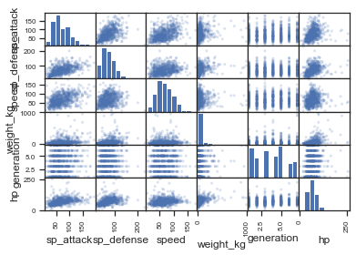

```python
df = pd.DataFrame(df_data, columns=['sp_attack','sp_defense','speed','weight_kg', 'generation', 'hp'])

pd.plotting.scatter_matrix(df, alpha=0.2)
```

### Colored Scatterplot Matrix

Select a categorical attribute and encode its values with color in the scatterplot matrix (e.g. with [altair](https://altair-viz.github.io/gallery/scatter_matrix.html) again or [seaborn pairplot](https://seaborn.pydata.org/generated/seaborn.pairplot.html#seaborn.pairplot)).

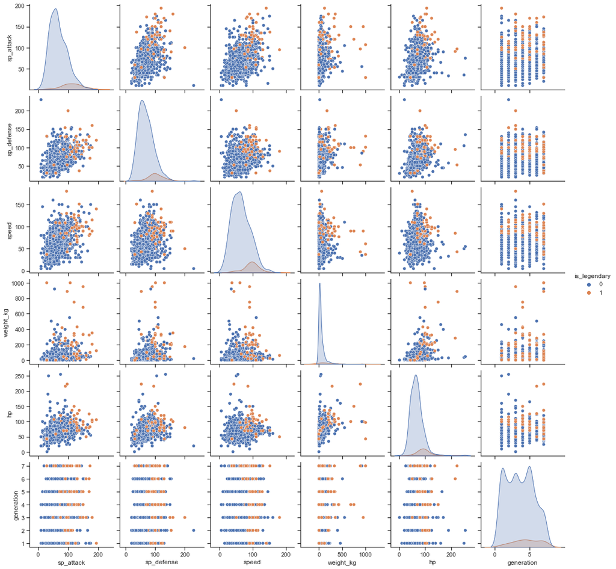

```python
# Plot the selected attributes again and color code the points by position
poke_sns = pd.DataFrame(df_data, columns=['sp_attack','sp_defense','speed','weight_kg', 'hp','generation', 'is_legendary'])

sns.pairplot(poke_sns, hue="is_legendary")
```

### Interpretation

Already in this visualization we are able to see that between there is a little bit of a linear dependancy between speed and attack as well as defense and attack. I have choosen the *is_legendary* variable instead of the generation for the sake of better distinction of the categorical variables.

## Task: Heat Map

Select suitable attributes and visualise the data in a heatmap, e.g. with [seaborn](https://seaborn.pydata.org/generated/seaborn.heatmap.html) or [altair](https://altair-viz.github.io/gallery/simple_heatmap.html).

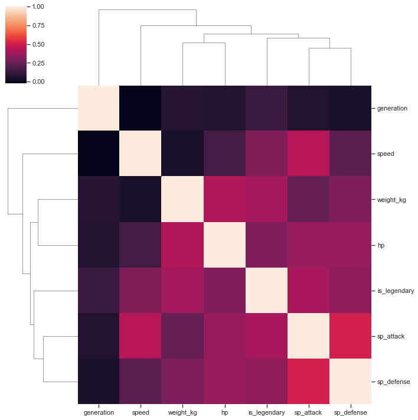

```python
#compute the correlations and take a look at them
corr_poke = poke_sns.corr()

# draw a clustered heatmap using seaborn
sns.clustermap(corr_poke, square=True)
```

## Submission

Please add your student information (name,student ID) and download this notebook as HTML (File > Export Notebook As... > Export Notebook to HTML) and submit it.